# UW Data Science 350

## Winter 2017

### Dave Wine 8430191

### Assignment #7 - Regression

# Summary

   For thres = 65 (all values) R^2 is 0.953 - nearly identical to the Stepwise analysis - but not better.

   For thres = 50 (near dropoff on mSVD plot), R^2 is basically unchanged.

   For thres = 13, R^2 is somewhat worse than the Stepwise (0.86 vs. 0.95) so that is probably too many.

   thres = 30 gives an R^2 of 0.91, so even there we are seeing significant degradation.
3. Elastic Net:

   lambda = 5: R^2 = 0.824

   lambda = 10: R^2 = 0.937

   lambda = 15: R^2 = 0.956

   lambda = 20: R^2 = 0.958

It seems like a lambda of betweeen 10 and 15 is as good as we need here to converge, at least using R^2.

This model does as well as the others from an R^2 standpoint.

All three models appear to be about the same in their predictive capability, at least based on R^2.

```r
## Libraries
require ('MASS')
require ('repr')
require ('ggplot2')
require ('dplyr')
require ('HistData')
require ('glmnet')
require ('gridExtra')
```

```r
### Functions

# File read function
read.auto = function(file = 'Automobile price data _Raw_.csv'){
  auto.data <- read.csv(file, header=TRUE, stringsAsFactors=FALSE)

  numcols <- c('bore','stroke','horsepower','price','peak.rpm')
  auto.data[, numcols]<-lapply(auto.data[,numcols], as.numeric)

  factcols <- c('make','fuel.type','aspiration','num.of.doors','drive.wheels','engine.location','engine.type','num.of.cylinders','fuel.system','body.style')
  auto.data[, factcols]<-lapply(auto.data[,factcols], as.factor)

  auto.data[complete.cases(auto.data),]
}

# Plot function
plot.svd.reg <- function(df, k = 4,modelname){
  require(ggplot2)
  require(gridExtra)

  p1 <- ggplot(df) +
    geom_point(aes(score, resids), size = 2) +
    stat_smooth(aes(score, resids)) +
    ggtitle(paste('Residuals vs. fitted values: ',modelname))

  p2 <- ggplot(df, aes(resids)) +
    geom_histogram(aes(y = ..density..)) +
    geom_density(color = 'red', fill = 'red', alpha = 0.2) +
    ggtitle(paste('Histogram of residuals: ',modelname))

  qqnorm(df$resids,main=paste("Normal Q-Q Plot: ",modelname))

  grid.arrange(p1, p2, ncol = 2)

  df$std.resids = sqrt((df$resids - mean(df$resids))^2)

  p3 = ggplot(df) +
    geom_point(aes(score, std.resids), size = 2) +
    stat_smooth(aes(score, std.resids)) +
    ggtitle(paste('Standardized residuals vs. fitted values: ',modelname))
  print(p3)

  n = nrow(df)
  Ybar = mean(df$price)
  SST <- sum((df$price - Ybar)^2)
  SSR <- sum(df$resids * df$resids)
  SSE = SST - SSR
  cat(paste('SSE =', as.character(SSE), '\n'))
  cat(paste('SSR =', as.character(SSR), '\n'))
  cat(paste('SST =', as.character(SSE + SSR), '\n'))
  cat(paste('RMSE =', as.character(SSE/(n - 2)), '\n'))

  adjR2  <- 1.0 - (SSR/SST) * ((n - 1)/(n - k - 1))
  cat(paste('Adjusted R^2 =', as.character(adjR2)), '\n')
}

# Plot of glmnet stuff
EN.plot <-function(var,title){
plot(var, xvar = 'lambda', label = TRUE,main=title)
plot(var, xvar = 'dev', label = TRUE,main=title)
    }
```

```r
# Read data in
auto.data <- read.auto()

# View dataset and summary statistics
str(auto.data)

## Clean up dataset
# remove first two columns
auto.data <- auto.data[,-(1:2)]

# Transform price to log(price) based on previous work
auto.data$price <- log(auto.data$price)

# Check on factors
auto.mat <- model.matrix(price ~ ., data = auto.data)
auto.mat[1:10, ]
```

```
'data.frame':	195 obs. of  26 variables:
 $ symboling        : int  3 3 1 2 2 2 1 1 1 2 ...
 $ normalized.losses: chr  "?" "?" "?" "164" ...
 $ make             : Factor w/ 22 levels "alfa-romero",..: 1 1 1 2 2 2 2 2 2 3 ...
 $ fuel.type        : Factor w/ 2 levels "diesel","gas": 2 2 2 2 2 2 2 2 2 2 ...
 $ aspiration       : Factor w/ 2 levels "std","turbo": 1 1 1 1 1 1 1 1 2 1 ...
 $ num.of.doors     : Factor w/ 3 levels "?","four","two": 3 3 3 2 2 3 2 2 2 3 ...
 $ body.style       : Factor w/ 5 levels "convertible",..: 1 1 3 4 4 4 4 5 4 4 ...
 $ drive.wheels     : Factor w/ 3 levels "4wd","fwd","rwd": 3 3 3 2 1 2 2 2 2 3 ...
 $ engine.location  : Factor w/ 2 levels "front","rear": 1 1 1 1 1 1 1 1 1 1 ...
 $ wheel.base       : num  88.6 88.6 94.5 99.8 99.4 ...
 $ length           : num  169 169 171 177 177 ...
 $ width            : num  64.1 64.1 65.5 66.2 66.4 66.3 71.4 71.4 71.4 64.8 ...
 $ height           : num  48.8 48.8 52.4 54.3 54.3 53.1 55.7 55.7 55.9 54.3 ...
 $ curb.weight      : int  2548 2548 2823 2337 2824 2507 2844 2954 3086 2395 ...
 $ engine.type      : Factor w/ 7 levels "dohc","dohcv",..: 1 1 6 4 4 4 4 4 4 4 ...
 $ num.of.cylinders : Factor w/ 7 levels "eight","five",..: 3 3 4 3 2 2 2 2 2 3 ...
 $ engine.size      : int  130 130 152 109 136 136 136 136 131 108 ...
 $ fuel.system      : Factor w/ 8 levels "1bbl","2bbl",..: 6 6 6 6 6 6 6 6 6 6 ...
 $ bore             : num  3.47 3.47 2.68 3.19 3.19 3.19 3.19 3.19 3.13 3.5 ...
 $ stroke           : num  2.68 2.68 3.47 3.4 3.4 3.4 3.4 3.4 3.4 2.8 ...
 $ compression.ratio: num  9 9 9 10 8 8.5 8.5 8.5 8.3 8.8 ...
 $ horsepower       : num  111 111 154 102 115 110 110 110 140 101 ...
 $ peak.rpm         : num  5000 5000 5000 5500 5500 5500 5500 5500 5500 5800 ...
 $ city.mpg         : int  21 21 19 24 18 19 19 19 17 23 ...
 $ highway.mpg      : int  27 27 26 30 22 25 25 25 20 29 ...
 $ price            : num  13495 16500 16500 13950 17450 ...
```

|  | (Intercept) | makeaudi | makebmw | makechevrolet | makedodge | makehonda | makeisuzu | makejaguar | makemazda | makemercedes-benz | ... | fuel.systemmpfi | fuel.systemspdi | fuel.systemspfi | bore | stroke | compression.ratio | horsepower | peak.rpm | city.mpg | highway.mpg |
| --- | --- | --- | --- | --- | --- | --- | --- | --- | --- | --- | --- | --- | --- | --- | --- | --- | --- | --- | --- | --- | --- |
| 1 | 1 | 0 | 0 | 0 | 0 | 0 | 0 | 0 | 0 | 0 | ... | 1 | 0 | 0 | 3.47 | 2.68 | 9.0 | 111 | 5000 | 21 | 27 |
| 2 | 1 | 0 | 0 | 0 | 0 | 0 | 0 | 0 | 0 | 0 | ... | 1 | 0 | 0 | 3.47 | 2.68 | 9.0 | 111 | 5000 | 21 | 27 |
| 3 | 1 | 0 | 0 | 0 | 0 | 0 | 0 | 0 | 0 | 0 | ... | 1 | 0 | 0 | 2.68 | 3.47 | 9.0 | 154 | 5000 | 19 | 26 |
| 4 | 1 | 1 | 0 | 0 | 0 | 0 | 0 | 0 | 0 | 0 | ... | 1 | 0 | 0 | 3.19 | 3.40 | 10.0 | 102 | 5500 | 24 | 30 |
| 5 | 1 | 1 | 0 | 0 | 0 | 0 | 0 | 0 | 0 | 0 | ... | 1 | 0 | 0 | 3.19 | 3.40 | 8.0 | 115 | 5500 | 18 | 22 |
| 6 | 1 | 1 | 0 | 0 | 0 | 0 | 0 | 0 | 0 | 0 | ... | 1 | 0 | 0 | 3.19 | 3.40 | 8.5 | 110 | 5500 | 19 | 25 |
| 7 | 1 | 1 | 0 | 0 | 0 | 0 | 0 | 0 | 0 | 0 | ... | 1 | 0 | 0 | 3.19 | 3.40 | 8.5 | 110 | 5500 | 19 | 25 |
| 8 | 1 | 1 | 0 | 0 | 0 | 0 | 0 | 0 | 0 | 0 | ... | 1 | 0 | 0 | 3.19 | 3.40 | 8.5 | 110 | 5500 | 19 | 25 |
| 9 | 1 | 1 | 0 | 0 | 0 | 0 | 0 | 0 | 0 | 0 | ... | 1 | 0 | 0 | 3.13 | 3.40 | 8.3 | 140 | 5500 | 17 | 20 |
| 11 | 1 | 0 | 1 | 0 | 0 | 0 | 0 | 0 | 0 | 0 | ... | 1 | 0 | 0 | 3.50 | 2.80 | 8.8 | 101 | 5800 | 23 | 29 |

## Simple linear model

For reference, run a simple linear model first:

```
Call:
lm(formula = price ~ ., data = auto.data)

Residuals:
     Min       1Q   Median       3Q      Max
-0.26018 -0.05512  0.00000  0.06592  0.20811

Coefficients: (3 not defined because of singularities)
                         Estimate Std. Error t value Pr(>|t|)
(Intercept)             9.129e+00  1.059e+00   8.624 1.36e-14 ***
makeaudi                2.286e-01  1.355e-01   1.686 0.093983 .
makebmw                 4.409e-01  1.411e-01   3.124 0.002172 **
makechevrolet          -8.583e-02  1.384e-01  -0.620 0.536271
makedodge              -2.324e-01  1.137e-01  -2.044 0.042902 *
makehonda               1.015e-01  1.336e-01   0.759 0.448965
makeisuzu              -3.678e-01  1.498e-01  -2.455 0.015325 *
makejaguar             -3.593e-01  1.695e-01  -2.120 0.035832 *
makemazda              -2.466e-04  1.035e-01  -0.002 0.998102
makemercedes-benz       2.575e-02  1.522e-01   0.169 0.865920
makemercury             8.047e-03  1.786e-01   0.045 0.964124
makemitsubishi         -2.697e-01  1.128e-01  -2.391 0.018149 *
makenissan             -1.231e-02  1.023e-01  -0.120 0.904421
makepeugot             -6.401e-01  2.718e-01  -2.355 0.019924 *
makeplymouth           -2.443e-01  1.120e-01  -2.182 0.030832 *
makeporsche             4.212e-01  1.782e-01   2.363 0.019515 *
makesaab                1.966e-01  1.211e-01   1.623 0.106902
makesubaru             -1.494e-01  1.177e-01  -1.269 0.206439
maketoyota             -1.340e-01  9.562e-02  -1.401 0.163484
makevolkswagen         -1.147e-02  1.067e-01  -0.108 0.914533
makevolvo               3.575e-02  1.327e-01   0.269 0.788006
fuel.typegas           -8.278e-01  4.039e-01  -2.050 0.042292 *
aspirationturbo         9.542e-02  4.899e-02   1.948 0.053478 .
num.of.doorsfour        1.598e-02  8.577e-02   0.186 0.852463
num.of.doorstwo        -4.081e-02  9.086e-02  -0.449 0.654038
body.stylehardtop      -1.588e-01  7.212e-02  -2.202 0.029325 *
body.stylehatchback    -1.996e-01  6.702e-02  -2.978 0.003428 **
body.stylesedan        -1.788e-01  7.254e-02  -2.466 0.014904 *
body.stylewagon        -2.055e-01  7.862e-02  -2.613 0.009962 **
drive.wheelsfwd        -3.941e-02  5.616e-02  -0.702 0.484062
drive.wheelsrwd         4.811e-02  7.449e-02   0.646 0.519433
```

[output cut: 20 more lines]

```
fuel.systemspdi         1.628e-01  1.116e-01   1.459 0.146887
fuel.systemspfi         3.994e-01  1.853e-01   2.155 0.032881 *
bore                   -2.163e-01  1.116e-01  -1.939 0.054584 .
stroke                  3.426e-03  6.011e-02   0.057 0.954626
compression.ratio      -4.800e-02  2.976e-02  -1.613 0.108995
horsepower             -7.480e-04  1.488e-03  -0.503 0.616068
peak.rpm                2.425e-05  3.955e-05   0.613 0.540807
city.mpg               -1.837e-02  8.157e-03  -2.252 0.025870 *
highway.mpg             1.301e-02  6.992e-03   1.860 0.064948 .
---
Signif. codes:  0 '***' 0.001 '**' 0.01 '*' 0.05 '.' 0.1 ' ' 1

Residual standard error: 0.106 on 138 degrees of freedom
Multiple R-squared:  0.9691,	Adjusted R-squared:  0.9566
F-statistic: 77.36 on 56 and 138 DF,  p-value: < 2.2e-16
```

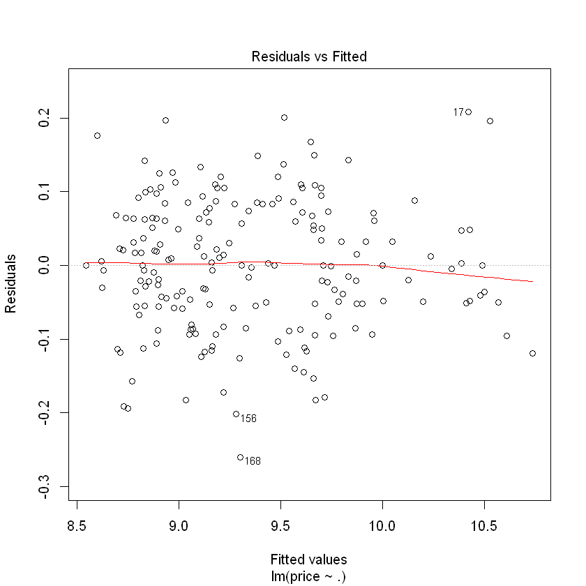

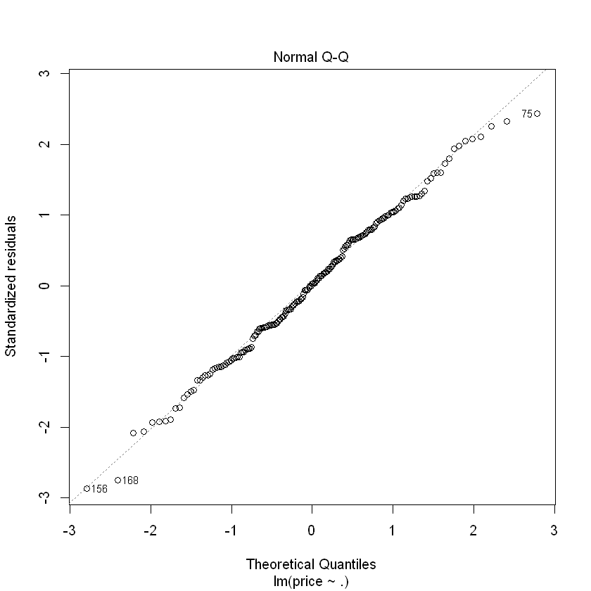

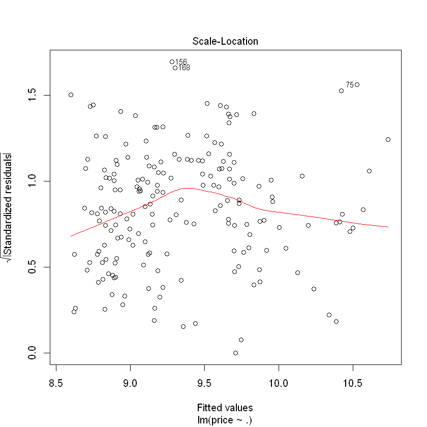

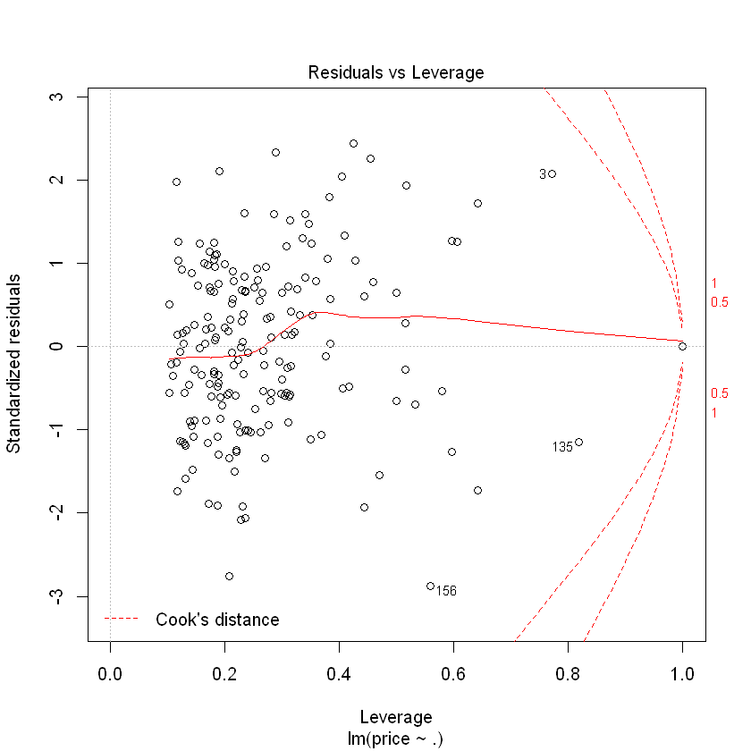

```r
# Simple linear model against all variables
lm.price <- lm(price ~ ., data = auto.data)
summary(lm.price)
plot(lm.price)
```

Apart from the intercept, weight and height seem to be the most important factors. Engine location, body style, and wheelbase may be significant. Some makes may also be significant (e.g. BMW). The residual distribution is pretty much normal.

## Stepwise Regression

Next, run a Stepwise Regression to better identity factors that are not significant:

```
Start:  AIC=-828.59
price ~ make + fuel.type + aspiration + num.of.doors + body.style +
    drive.wheels + engine.location + wheel.base + length + width +
    height + curb.weight + engine.type + num.of.cylinders + engine.size +
    fuel.system + bore + stroke + compression.ratio + horsepower +
    peak.rpm + city.mpg + highway.mpg


Step:  AIC=-828.59
price ~ make + fuel.type + aspiration + num.of.doors + body.style +
    drive.wheels + wheel.base + length + width + height + curb.weight +
    engine.type + num.of.cylinders + engine.size + fuel.system +
    bore + stroke + compression.ratio + horsepower + peak.rpm +
    city.mpg + highway.mpg


Step:  AIC=-828.59
price ~ make + aspiration + num.of.doors + body.style + drive.wheels +
    wheel.base + length + width + height + curb.weight + engine.type +
    num.of.cylinders + engine.size + fuel.system + bore + stroke +
    compression.ratio + horsepower + peak.rpm + city.mpg + highway.mpg

                    Df Sum of Sq    RSS     AIC
- stroke             1   0.00004 1.5515 -830.59
- horsepower         1   0.00284 1.5543 -830.24
- peak.rpm           1   0.00423 1.5557 -830.06
<none>                           1.5514 -828.59
- fuel.system        6   0.09857 1.6500 -828.58
- width              1   0.02038 1.5718 -828.05
- length             1   0.02108 1.5725 -827.96
- num.of.cylinders   4   0.07187 1.6233 -827.76
- num.of.doors       2   0.04263 1.5941 -827.31
- drive.wheels       2   0.04363 1.5951 -827.19
- compression.ratio  1   0.02926 1.5807 -826.95
- engine.size        1   0.03200 1.5835 -826.61
- highway.mpg        1   0.03891 1.5904 -825.76
- bore               1   0.04225 1.5937 -825.35
- aspiration         1   0.04265 1.5941 -825.31
- city.mpg           1   0.05704 1.6085 -823.55
- body.style         4   0.11434 1.6658 -822.73
```

[output cut: 80 more lines]

```
- engine.size        1   0.02957 1.5861 -832.28
+ peak.rpm           1   0.00226 1.5543 -832.24
+ horsepower         1   0.00088 1.5557 -832.06
+ stroke             1   0.00001 1.5565 -831.95
- highway.mpg        1   0.03620 1.5928 -831.47
- num.of.cylinders   4   0.08807 1.6446 -831.22
- aspiration         1   0.04347 1.6000 -830.58
- bore               1   0.04987 1.6064 -829.80
- city.mpg           1   0.05754 1.6141 -828.87
- body.style         4   0.12039 1.6770 -827.42
- wheel.base         1   0.10150 1.6581 -823.63
- engine.type        3   0.16814 1.7247 -819.95
- height             1   0.13317 1.6897 -819.94
- curb.weight        1   0.33000 1.8866 -798.46
- make              19   1.85756 3.4141 -718.79
```

| Step | Df | Deviance | Resid. Df | Resid. Dev | AIC |
| --- | --- | --- | --- | --- | --- |
|  | NA | NA | 138 | 1.551445 | -828.5934 |
| - engine.location | 0 | 1.332268e-15 | 138 | 1.551445 | -828.5934 |
| - fuel.type | 0 | 1.598721e-14 | 138 | 1.551445 | -828.5934 |
| - stroke | 1 | 3.652842e-05 | 139 | 1.551482 | -830.5888 |
| - horsepower | 1 | 2.814223e-03 | 140 | 1.554296 | -832.2355 |
| - peak.rpm | 1 | 2.260803e-03 | 141 | 1.556557 | -833.9520 |

```
Call:
lm(formula = price ~ make + aspiration + num.of.doors + body.style +
    drive.wheels + wheel.base + length + width + height + curb.weight +
    engine.type + num.of.cylinders + engine.size + fuel.system +
    bore + compression.ratio + city.mpg + highway.mpg, data = auto.data)

Residuals:
     Min       1Q   Median       3Q      Max
-0.26258 -0.05555  0.00000  0.06920  0.21369

Coefficients: (1 not defined because of singularities)
                         Estimate Std. Error t value Pr(>|t|)
(Intercept)             8.481e+00  8.794e-01   9.644  < 2e-16 ***
makeaudi                2.427e-01  1.264e-01   1.920 0.056920 .
makebmw                 4.643e-01  1.239e-01   3.748 0.000259 ***
makechevrolet          -6.670e-02  1.250e-01  -0.534 0.594440
makedodge              -2.078e-01  1.008e-01  -2.062 0.041047 *
makehonda               1.195e-01  1.206e-01   0.991 0.323603
makeisuzu              -3.521e-01  1.464e-01  -2.405 0.017492 *
makejaguar             -3.140e-01  1.494e-01  -2.101 0.037406 *
makemazda               1.488e-02  9.728e-02   0.153 0.878608
makemercedes-benz       4.303e-02  1.467e-01   0.293 0.769753
makemercury             2.417e-03  1.593e-01   0.015 0.987919
makemitsubishi         -2.480e-01  1.016e-01  -2.441 0.015889 *
makenissan              4.783e-03  9.188e-02   0.052 0.958558
makepeugot             -5.971e-01  2.583e-01  -2.311 0.022264 *
makeplymouth           -2.200e-01  9.942e-02  -2.213 0.028491 *
makeporsche             4.322e-01  1.630e-01   2.651 0.008950 **
makesaab                2.011e-01  1.099e-01   1.830 0.069394 .
makesubaru             -5.830e-01  2.001e-01  -2.913 0.004164 **
maketoyota             -1.223e-01  9.052e-02  -1.351 0.178911
makevolkswagen          7.413e-03  9.737e-02   0.076 0.939425
makevolvo               5.970e-02  1.170e-01   0.510 0.610592
aspirationturbo         7.772e-02  3.917e-02   1.984 0.049149 *
num.of.doorsfour        1.078e-02  8.441e-02   0.128 0.898604
num.of.doorstwo        -4.457e-02  8.962e-02  -0.497 0.619708
body.stylehardtop      -1.620e-01  7.024e-02  -2.307 0.022513 *
body.stylehatchback    -2.025e-01  6.505e-02  -3.113 0.002244 **
body.stylesedan        -1.806e-01  7.061e-02  -2.558 0.011580 *
body.stylewagon        -2.062e-01  7.726e-02  -2.668 0.008520 **
```

[output cut: 18 more lines]

```
fuel.systemidi          7.570e-01  3.794e-01   1.995 0.047974 *
fuel.systemmfi          1.568e-01  1.571e-01   0.998 0.319864
fuel.systemmpfi         1.811e-01  9.109e-02   1.988 0.048693 *
fuel.systemspdi         1.532e-01  1.095e-01   1.398 0.164227
fuel.systemspfi         3.908e-01  1.830e-01   2.136 0.034430 *
bore                   -2.190e-01  1.030e-01  -2.126 0.035286 *
compression.ratio      -4.249e-02  2.750e-02  -1.545 0.124476
city.mpg               -1.823e-02  7.984e-03  -2.283 0.023927 *
highway.mpg             1.240e-02  6.846e-03   1.811 0.072275 .
---
Signif. codes:  0 '***' 0.001 '**' 0.01 '*' 0.05 '.' 0.1 ' ' 1

Residual standard error: 0.1051 on 141 degrees of freedom
Multiple R-squared:  0.969,	Adjusted R-squared:  0.9574
F-statistic: 83.23 on 53 and 141 DF,  p-value: < 2.2e-16
```

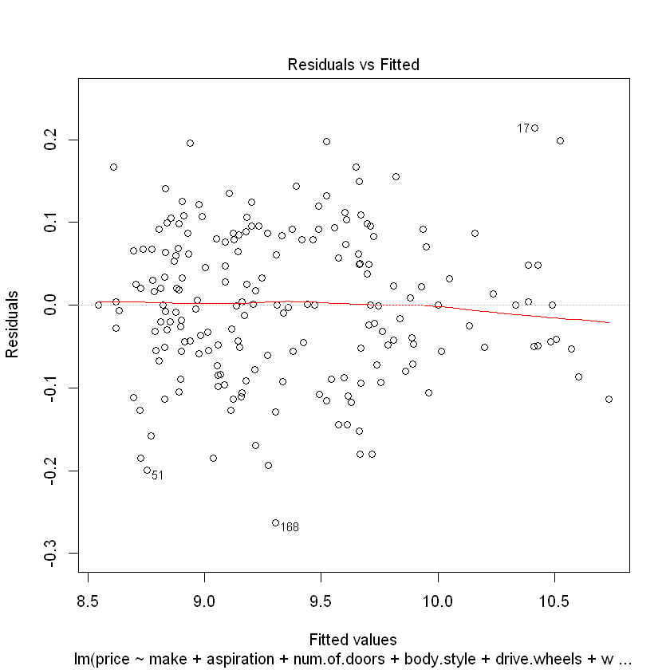

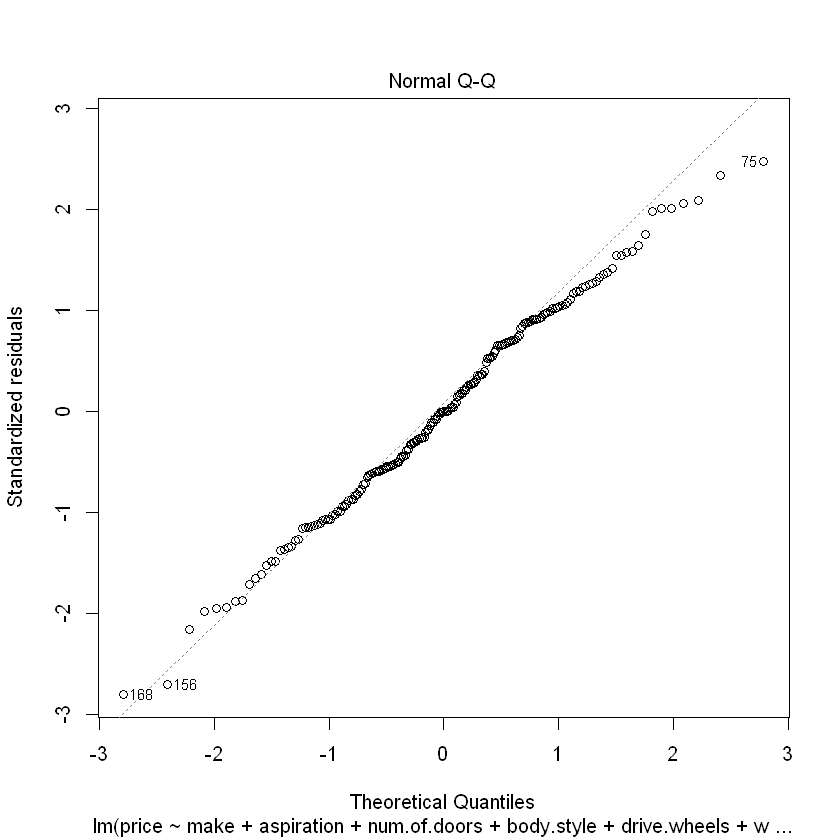

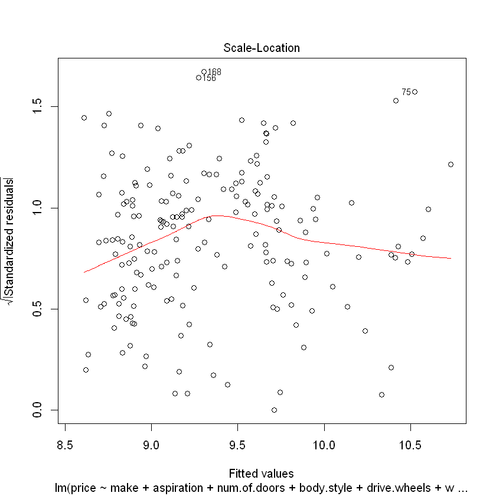

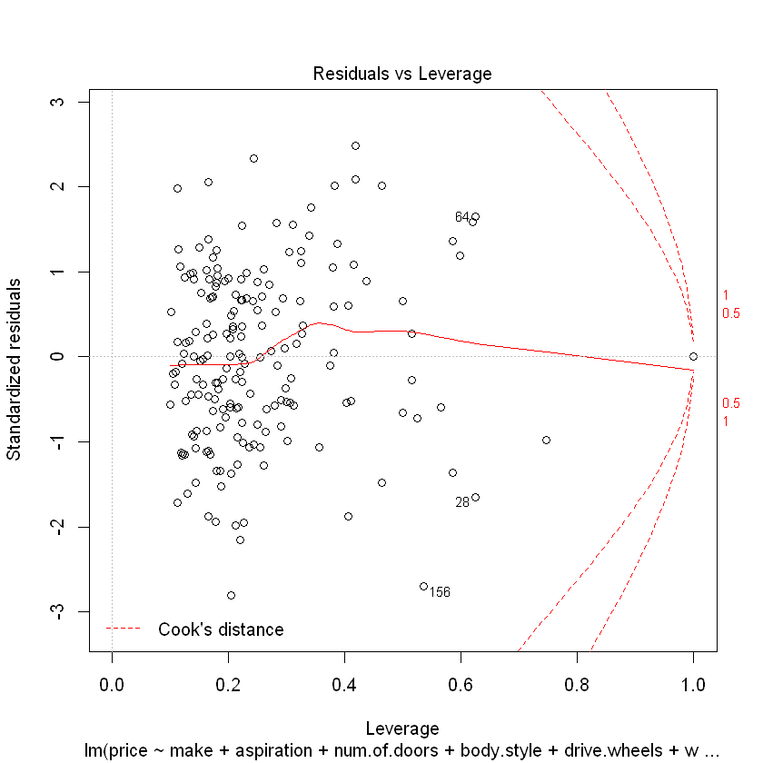

```r
### Stepwise Regression
lm.step <- stepAIC(lm.price, direction = 'both')
lm.step$anova # ANOVA of the result
summary(lm.step) # Summary of the best model
plot(lm.step)
```

The Stepwise regression eliminated engine location, fuel type, stroke, HP, and peak rpm as significant variables. The standard error and R^2 values between Stepwise and standard models are nearly identical, so in this case it does not appear that Stepwise regression helps much.

## SVD

Run a singular value decomposition with no bias:

|  | (Intercept) | makeaudi | makebmw | makechevrolet | makedodge | makehonda | makeisuzu | makejaguar | makemazda | makemercedes-benz | ... | fuel.systemmpfi | fuel.systemspdi | fuel.systemspfi | bore | stroke | compression.ratio | horsepower | peak.rpm | city.mpg | highway.mpg |
| --- | --- | --- | --- | --- | --- | --- | --- | --- | --- | --- | --- | --- | --- | --- | --- | --- | --- | --- | --- | --- | --- |
| (Intercept) | 195 | 6 | 8 | 3 | 9 | 13 | 2 | 3 | 13 | 8 | ... | 89 | 9 | 1 | 649.23 | 633.81 | 1988.02 | 20138 | 994400 | 4948 | 6014 |
| makeaudi | 6 | 6 | 0 | 0 | 0 | 0 | 0 | 0 | 0 | 0 | ... | 6 | 0 | 0 | 19.08 | 20.40 | 51.80 | 687 | 33000 | 116 | 147 |
| makebmw | 8 | 0 | 8 | 0 | 0 | 0 | 0 | 0 | 0 | 0 | ... | 8 | 0 | 0 | 27.79 | 25.34 | 68.60 | 1111 | 40550 | 155 | 203 |
| makechevrolet | 3 | 0 | 0 | 3 | 0 | 0 | 0 | 0 | 0 | 0 | ... | 0 | 0 | 0 | 8.97 | 9.25 | 28.70 | 188 | 15900 | 123 | 139 |
| makedodge | 9 | 0 | 0 | 0 | 9 | 0 | 0 | 0 | 0 | 0 | ... | 2 | 0 | 0 | 27.85 | 30.29 | 77.71 | 777 | 48500 | 252 | 307 |
| makehonda | 13 | 0 | 0 | 0 | 0 | 13 | 0 | 0 | 0 | 0 | ... | 1 | 0 | 0 | 39.28 | 45.01 | 119.80 | 1043 | 74800 | 395 | 461 |
| makeisuzu | 2 | 0 | 0 | 0 | 0 | 0 | 2 | 0 | 0 | 0 | ... | 0 | 0 | 1 | 6.74 | 6.46 | 17.70 | 168 | 9800 | 48 | 58 |
| makejaguar | 3 | 0 | 0 | 0 | 0 | 0 | 0 | 3 | 0 | 0 | ... | 3 | 0 | 0 | 10.80 | 11.10 | 27.70 | 614 | 14500 | 43 | 55 |
| makemazda | 13 | 0 | 0 | 0 | 0 | 0 | 0 | 0 | 13 | 0 | ... | 1 | 0 | 0 | 42.73 | 42.89 | 140.70 | 1016 | 62850 | 370 | 451 |
| makemercedes-benz | 8 | 0 | 0 | 0 | 0 | 0 | 0 | 0 | 0 | 8 | ... | 4 | 0 | 0 | 28.84 | 27.46 | 118.60 | 1170 | 35900 | 148 | 168 |

1. 6396831408.29727

2. 62245844.0548035

3. 200966.618324359

4. 51161.6506848336

5. 18001.5298274673

6. 5983.7553931583

7. 1496.73761923722

8. 1059.1933354482

9. 561.143632011866

10. 389.276483561278

11. 184.449643811774

12. 88.7439720413675

13. 64.1425049763518

14. 48.4505124805419

15. 37.0483300909248

16. 34.2334877963792

17. 30.614015121722

18. 21.6739706169468

19. 19.9431925475161

20. 19.0391611755721

21. 16.8948002866434

22. 15.2579209136773

23. 12.0789076026275

24. 11.8511323507439

25. 10.4657194584219

26. 9.46939414347865

27. 8.55432367528839

28. 8.10674833591516

29. 7.60104352443092

30. 6.92905150367737

31. 6.43798403541123

32. 4.83460432851628

33. 4.16801306946917

34. 3.81922363299159

35. 3.37229118059971

36. 3.16570730450501

37. 2.62100509888222

38. 2.29332186192305

39. 1.79101671377268

40. 1.60522682965957

41. 1.36833530276734

42. 1.27226330662471

43. 1.16893706891578

44. 1.02983758205271

45. 0.896749203383686

46. 0.84901703328856

47. 0.71003725838811

48. 0.663826096028885

49. 0.445123226987235

50. 0.418670078036092

51. 0.384123399007427

52. 0.299247596929072

53. 0.188212911303988

54. 0.1169464706298

55. 0.0676139454324501

56. 0.0491163554788828

57. 0.0167453585546971

58. 2.3147683555624e-06

59. 6.39171732583682e-07

60. 6.39171732583682e-07

61. 6.39171732583682e-07

62. 6.39171732583682e-07

63. 6.39171732583682e-07

64. 6.39171732583682e-07

65. 6.39171732583682e-07

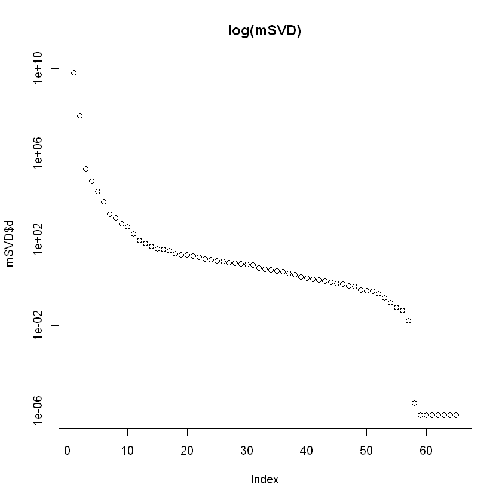

```r
### SVD
M = as.matrix(auto.mat)
MTM = t(M) %*% M
MTM[1:10,]

# Create mSVD
mSVD <- svd(MTM)
mSVD$d

plot(mSVD$d,log="y",main ="log(mSVD)")
```